# Untitled

I made my very first Xaringan presentation a few months ago. Of course I didn’t take the time to learn it slowly and without pressure. No, I decided to swap to Xaringan just before a talk at satRdays Amsterdam. I had a lot of code chunks and normal Rmarkdown slides only showed a fraction of the code without giving me a lot of flexibility. The other option copy pasting snippets to Powerpoint wasn’t really what I wanted to do.

So Xaringan it was.  
There is a lot of information about Xaringan: wiki’s, blog posts (see resources below). Many of these resources are brilliant, and I would advice everyone to browse through them as well. However most people will likely be like me: you don’t start on Xaringan when you have no slides to make, you start when you are busy with them and having to browse through many resources that often have beginners and advanced things mixed throughout is not so easy. I had 8 tabs open with examples and every time i wanted to do something I went browsing through all of them.

These blog posts want to build on that material. This contain the version of what I would have wanted to see: the essentials and some easy tricks that would have enabled me to focus on content rather than form, and build up more slowly once I knew what I was doing.

For these tutorials, I assume that you know the basics of markdown/R Markdown. If that is not the case, you might want to first learn that. The [R Markdown website is a good start](https://rmarkdown.rstudio.com/lesson-1.html).

# Getting started

### Installing xaringan

To install the latest CRAN version: `install.packages("xaringan")` You can also install the latest development version from github: `devtools::install_github('yihui/xaringan')`

### Your first xaringan presentation:

Go to New > R Markdown > from Template > Ninja presentation {xaringan}

At the very top in the YAML header, change the title, author date, but leave everything else for now (we’ll get to YAML options later). Below the YAML is a large presentation on Xaringan made by Yihui. It contains a ton of information on everything you do. And I would advice to look through it at some point, but if this is your first xaringan my advice would be to delete everything below the first code chunk. Because a lot of info has the power to confuse as well…

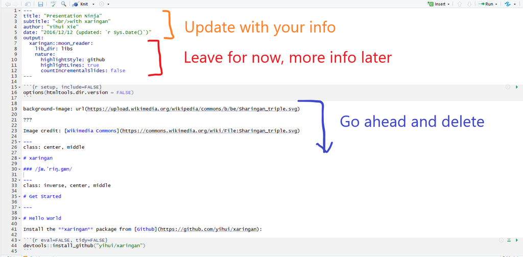

### Making your first slides

The basic rules of slide-making: - Different slides are separated by three dashes. - The text content of the slides follows traditional markdown formatting with #, ##, ### indicating different header levels.

```
# Title slide 1

Content slide 1
More content slide 1


---

# Title slide 2

### Subtitle
Lorem ipsum dolor sit amet, consectetur adipiscing elit, sed do eiusmod tempor incididunt ut labore et dolore magna aliqua.
```

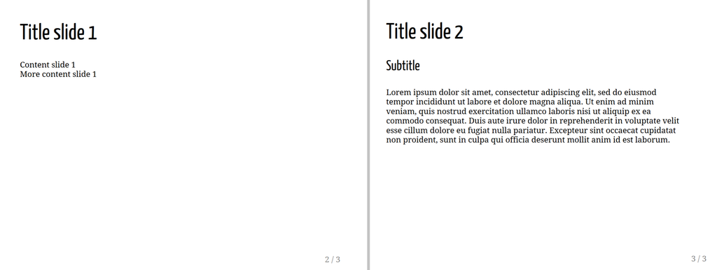

You can make the usual markdown bullet lists. And you make slides with ‘incremental’ slides (i.e. slide content appearing block by block rather than in one go) by adding two dashes `--` where you want to ‘click’. In the below example, each item of a bullet list will appear one by one.

```
---

# Title

+ Content I want to see first

--

+ Content I want to see added after clicking

--

+ Content I want to see added after clicking a second time

---
```

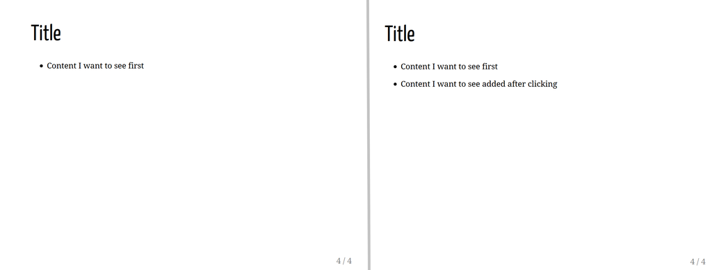

### Adding images

Adding images is a must for presentations. And there are a few options.

#### Option 1: using background images

One of the easiest ways is to use `background-image`:  
At the very top of your slide (before any class indications)

The advantage of using `background-image` is that’s very flexible: you can make your image full slide or small, and you have a lot of flexibility on the position of your image as well.

By default, your image is put in the center of the slide and maintains its original size.

```
---

background-image: url(images/network.jpg)

# Title

Slide content

---
```

For a ‘real’ background image, the intent is usually to fill the full slide. You can set the `background-dize: cover` to achieve this. Any titles or text you add will be written on top. You might want to change the alignment of the text to have it sit left center. How to do this will be explained below.

```
---

background-image: url(images/bulb.jpg)
background-size: cover

# Background-image

Slide content

---
```

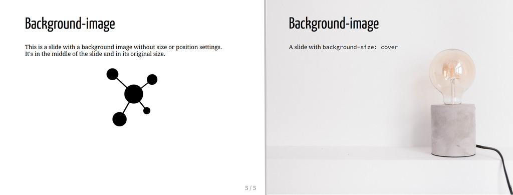

For other images, size and position can be modified until you have what you want: + To adapt the size: you can add a size in pixels to the `background-size` argument + To adjust the position, you add first the horizontal position, then the vertical position.

```
---

background-image: url(images/network_medium.png)
background-size: 100px
background-position: 0% 0%


# Background-image

Slide content

---
```

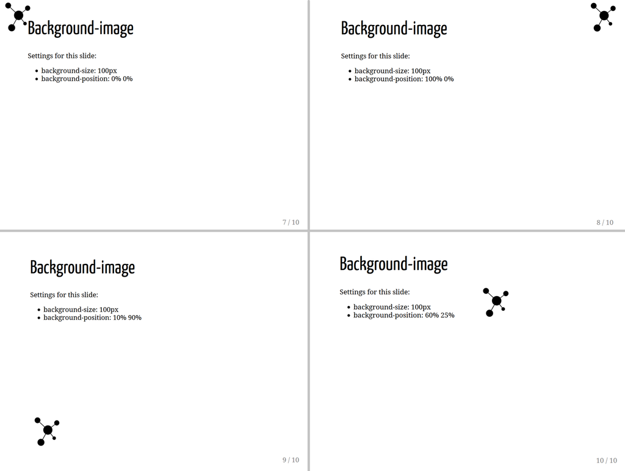

If you want more than one image in the background-image way, you can add multiple images with a comma:

```
---

background-image: url(images/network_medium.png), url(images/cloud.png)
background-size: 100px, 100px
background-position: 10% 90%, 30% 90%

# Two background images

Slide content

---
```

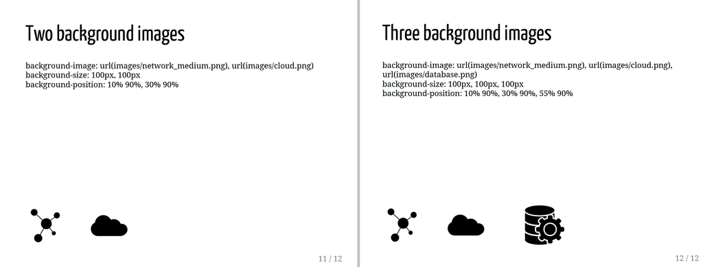

#### Option 2: using markdown images

Using background images gives you a lot of flexibility on size and position, but sometimes you need trial and error to get the position right. If you want your images in a certain spot versus text, this can be annoying - especially if you’re editing slides until the end.

One other way to add images is using traditional markdown. It will show images inline with your text, but the downside is that you have no control over size, so these images already need to be scaled correctly before adding.

```
# Markdown images

### Network considerations ![](images/network_small.png)

Lorem ipsum dolor sit amet, consectetur adipiscing elit, sed do eiusmod tempor incididunt ut labore et dolore magna aliqua.

### Cloud considerations ![](images/cloud_small.png)

Lorem ipsum dolor sit amet, consectetur adipiscing elit, sed do eiusmod tempor incididunt ut labore et dolore magna aliqua.
```

You have some control over position of the images, but not much. You can use the content classes to put an images left, center or right. (see later)

```
---
class: middle

.center[
![](images/network_small.png)
## Part 1: Network considerations

<br>

![](images/cloud_small.png)
## Part 2: Cloud considerations
]

---
```

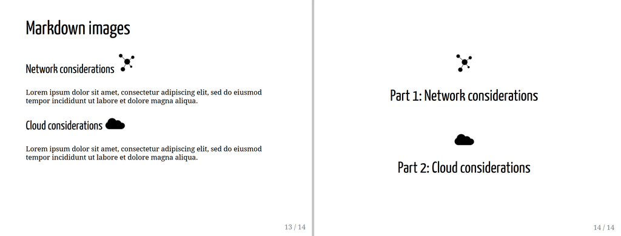

#### Option 3: using HTML images

If you want inline, but you also want control over the size of the pictures, you also have the option to leverage HTML code inside your slides:

```
---

# HTML images

I will add a picture right here:
<img src="images/database.png" width="100">

And perhaps one more here:
<img src="images/cloud.png" width="100">

---
```

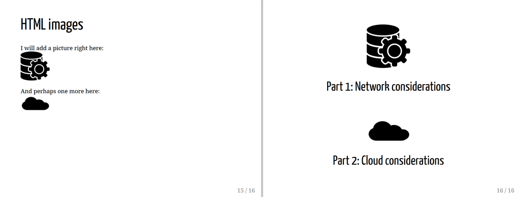

### Slide numbers

There are people who love slide numbers. I’m not one of them. Luckily there are ways to control slide numbers, and there right in the YAML header.

The default is is showing both the current slide and the total number of slides. You can add a `slideNumberFormat` argument inside the `nature` argument.  
+ To display only the current slide number, you can add `slideNumberFormat: "%current%"` + To display no slide number, you can add `slideNumberFormat: ""`

```
title: "Getting more out of Xaringan"
author: "Suzan Baert"
output:
  xaringan::moon_reader:
    lib_dir: libs
    nature:
      highlightStyle: github
      highlightLines: true
      slideNumberFormat: ""
```